# SST encounters tidyverse

Some doodle for PGNAPES

Ziggy and the Spider

```r
library(raster)
library(tidyverse)
# devtools::install_github("einarhjorleifsson/gisland", dependencies = FALSE)
```

TODO: Include documentation of downloading from source. For now check the [nco-scripts directory](https://github.com/sigurdurthorjonsson/myoisst/tree/master/nco-scripts) on Ziggy’s repo.

TODO2: Similar plots for May and June have been requested by members of the survey group.

The rendered html result has been added to the repo in order to make it possible to see the results without running the this Rmd-file.

Read in data:

```r
years <- 2010:2018

# seeding
res <- list()

# stack the hay
for(i in seq(along = years)) {
  res[[i]] <-
    raster(paste("macArea", years[i],
                 "m07.nc", sep = "/"), varname = "sst") %>%
    # User can change spatial resolution of temperature grid in the next step.
    #  Higher values mean faster plot rendering.
    aggregate(fac = 2) %>%
    as("SpatialPixelsDataFrame") %>%
    as.data.frame() %>%
    as_tibble() %>%
    rename(sst = Daily.sea.surface.temperature) %>%
    mutate(year = years[i])
}

# bind the hay
d <-
  res %>%
  bind_rows()
```

What have we got?:

```r
glimpse(d)
```

```
## Observations: 63,117
## Variables: 4
## $ sst  <dbl> -1.7029032, -1.7004838, -1.7012902, -1.7135484, -1.705322...
## $ x    <dbl> -19.25, -18.75, -18.25, -17.75, -17.25, -16.75, -16.25, -...
## $ y    <dbl> 79.75, 79.75, 79.75, 79.75, 79.75, 79.75, 79.75, 79.75, 7...
## $ year <int> 2010, 2010, 2010, 2010, 2010, 2010, 2010, 2010, 2010, 201...
```

Get a background map of terrestrial reference areas:

```r
m <- map_data("world", xlim = c(-50, 50), ylim = c(30, 85))
```

The sst plot (Be patient, takes some time to render. Or worse, if you got a lousy computer you will have a meltdown. In that case ask your boss for a real a computer that can do some modern day number crunching):

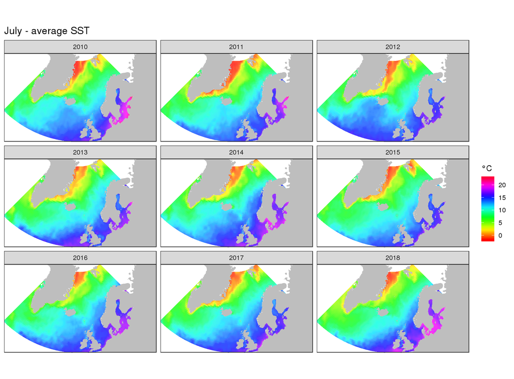

```r
# Find plot range
xlim <- range(d$x)
ylim <- range(d$y)

# The number of "steps" in the rainbow:
nlev <- d$sst %>% floor() %>% unique() %>% length()

d %>%
  ggplot() +
  theme_bw() +
  geom_tile(aes(x=x, y=y, fill=sst), alpha=0.8) +
  scale_fill_gradientn(colours = rainbow(nlev)) +
  geom_polygon(data = m, aes(long, lat, group = group), fill = "grey") +
  coord_map(projection = "azequalarea",
            xlim = xlim, ylim = ylim) +
  scale_x_continuous(name = NULL, breaks = NULL) +
  scale_y_continuous(name = NULL, breaks = NULL) +
  labs(title = "July - average SST",
       fill = "°C") +
  facet_wrap(~ year)
```

Calculate annual anomalies by “square”:

```r
d <-
  d %>%
  group_by(x, y) %>%
  mutate(anomaly = sst - mean(sst)) %>%
  ungroup()
```

Check the anomaly distribution:

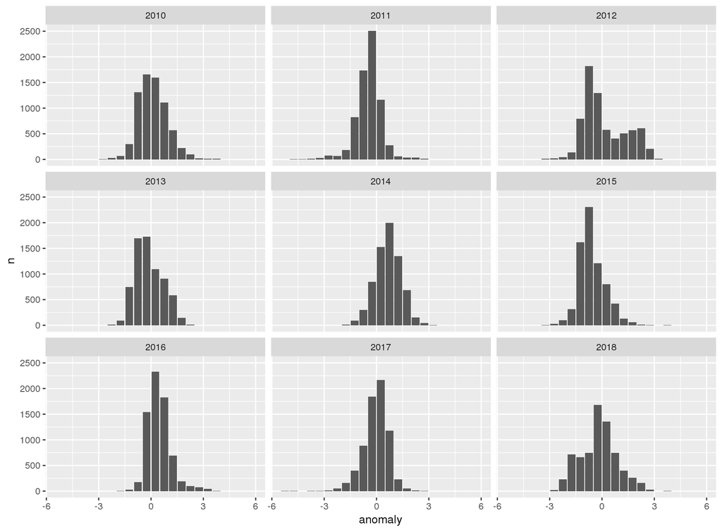

```r
d %>%
  mutate(anomaly = gisland::grade(anomaly, 0.5)) %>%
  group_by(year, anomaly) %>%
  count() %>%
  ggplot(aes(anomaly, n)) +
  geom_col() +
  facet_wrap(~ year)
```

Anomalies beyond c(-3, 3) are all but extremes (at least at the aggregation of 2 on the raw data), hence for the plotting lets trim the extremes:

```r
amin <- -3
amax <- 3
d <-
  d %>%
  # "Trim" the exremes, used in the plotting
  mutate(a.plot = case_when(anomaly < amin ~ amin,
                       anomaly > amax ~ amax,
                       TRUE ~ anomaly),
         a.plot = gisland::grade(a.plot, 0.5))
```